# MC_achilles

4 prism.achilles

4.1 Cleanup of prism.achilles

4.1.1 na removal

```r
# Where are our NAs?
which(is.na(prism.achilles[,14]))
```

```
## [1] 277 323
```

```r
prism.achilles[275:280,14]
```

```
## [1] -0.028821097  0.092031824           NA  0.100156084  0.051651937
## [6] -0.003150406
```

```r
prism.achilles[320:325,14]
```

```
## [1] -0.21325586 -0.06681872  0.25195944          NA -0.08459803  0.09666667
```

```r
# vector with NA rows - na.achilles
na.achilles <- c(277,309,323)
# Depmap ids of NA containing cellines
rownames(prism.achilles[na.achilles,])
```

```
## [1] "ACH-000836" "ACH-000901" "ACH-000939"
```

```r
# how many total NAs?
sum(is.na(prism.achilles[na.achilles,]))
```

```
## [1] 3302
```

```r
# removing NA containing rows from achilles
prism.achilles <- prism.achilles[-na.achilles,]
# checking if any NAs left
sum(is.na(prism.achilles))
```

```
## [1] 0
```

```r
# checking dim of prism.achilles - no genes removed - only NA cell lines removed
dim(prism.achilles)
```

```
## [1]   347 18119
```

4.1.2 Make Prism.achilles numeric

```r
prism.achilles.numeric <- apply(prism.achilles, 2, as.numeric)
# step below conserves rownames
rownames(prism.achilles.numeric) <- rownames(prism.achilles)
```

10.Intermission - Sort Prism.cl by depmap_id resulting in prism.cl.ordered

```r
# show slice of prism.cl - rows are not yet ordered
prism.cl[1:3,1:3]
```

```
##    DepMap_ID stripped_cell_line_name            CCLE_Name
## 1 ACH-000052                    A673            A673_BONE
## 2 ACH-000082         G292CLONEA141B1 G292CLONEA141B1_BONE
## 3 ACH-000087                   SKES1           SKES1_BONE
```

```r
# order prism.cl by DepMap_ID resulting in prism.cl.ordered
prism.cl.ordered <- prism.cl[order(prism.cl$DepMap_ID),]
# dimmension check - hasn't changed
dim(prism.cl.ordered)
```

```
## [1] 481  41
```

```r
# rownames are scrambled now -> reset
rownames(prism.cl.ordered) <- 1:nrow(prism.cl.ordered)
# check rowname order
rownames(prism.cl.ordered)[1:30]
```

```
##  [1] "1"  "2"  "3"  "4"  "5"  "6"  "7"  "8"  "9"  "10" "11" "12" "13" "14" "15"
## [16] "16" "17" "18" "19" "20" "21" "22" "23" "24" "25" "26" "27" "28" "29" "30"
```

```r
# check slice - everything worked
prism.cl.ordered[1:30,1:3]
```

```
##     DepMap_ID stripped_cell_line_name                     CCLE_Name
## 1  ACH-000007                   LS513         LS513_LARGE_INTESTINE
## 2  ACH-000008                   A101D                    A101D_SKIN
## 3  ACH-000011                    253J            253J_URINARY_TRACT
## 4  ACH-000012                  HCC827                   HCC827_LUNG
## 5  ACH-000013                 ONCODG1                 ONCODG1_OVARY
## 6  ACH-000014                  HS294T                   HS294T_SKIN
## 7  ACH-000015                NCIH1581                 NCIH1581_LUNG
## 8  ACH-000018                     T24             T24_URINARY_TRACT
## 9  ACH-000019                    MCF7                   MCF7_BREAST
## 10 ACH-000021                NCIH1693                 NCIH1693_LUNG
## 11 ACH-000022               PATU8988S            PATU8988S_PANCREAS
## 12 ACH-000023               PATU8988T            PATU8988T_PANCREAS
## 13 ACH-000026                  253JBV          253JBV_URINARY_TRACT
## 14 ACH-000027                    GOS3   GOS3_CENTRAL_NERVOUS_SYSTEM
```

[output cut: 16 more lines]

```r
# vector a with length of nrow prism.cl
a <- c(1:nrow(prism.cl.ordered))
# because prism cl is ordered we can easily remove the cellines, that have no achilles value, from prism.cl.ordered
# This loop checks if a certain celline has an achilles value and correspondingly writes a 0 or 1 into vector a
for(n in 1:481) {a[n] <- (prism.cl.ordered[n,1] %in% rownames(prism.achilles))}
# vector b contains the prism.cl rows / cellines that do not have an achilles value
b <- which(a == 0)
# remove prism.cl rows that don't have a corresponding achilles value
prism.cl.ordered.achilles <- prism.cl.ordered[-b, ]
# check dimensions of prism.cl.ordered.achilles
dim(prism.cl.ordered.achilles)
```

```
## [1] 347  41
```

```r
# reset rownames of prism.cl.ordered.achilles
rownames(prism.cl.ordered.achilles) <- 1:nrow(prism.cl.ordered.achilles)
# compare rownames of achilles with cl - checking for same order and same elements - they are equal
prism.cl.ordered.achilles[1:5,1]
```

```
## [1] "ACH-000007" "ACH-000011" "ACH-000012" "ACH-000013" "ACH-000014"
```

```r
rownames(prism.achilles.numeric)[1:5]
```

```
## [1] "ACH-000007" "ACH-000011" "ACH-000012" "ACH-000013" "ACH-000014"
```

Find PanCan Cellines in prism.cl.achilles

```r
# pancan.rownumbers is a vector with the row numbers that are pancreatic cancer cellines
pancan.rownumbers <- c(which(prism.cl.ordered.achilles[,20] == 'Pancreatic Cancer'))
# pancan.cl.names contains the DepMap IDs of the pancan cellines
pancan.cl.names <- prism.cl.ordered.achilles[pancan.rownumbers,1]
# checking if this was done correctly
prism.cl.ordered.achilles[pancan.rownumbers,20]
```

```
##  [1] "Pancreatic Cancer" "Pancreatic Cancer" "Pancreatic Cancer"
##  [4] "Pancreatic Cancer" "Pancreatic Cancer" "Pancreatic Cancer"
##  [7] "Pancreatic Cancer" "Pancreatic Cancer" "Pancreatic Cancer"
## [10] "Pancreatic Cancer" "Pancreatic Cancer" "Pancreatic Cancer"
## [13] "Pancreatic Cancer" "Pancreatic Cancer" "Pancreatic Cancer"
## [16] "Pancreatic Cancer" "Pancreatic Cancer" "Pancreatic Cancer"
## [19] "Pancreatic Cancer" "Pancreatic Cancer" "Pancreatic Cancer"
## [22] "Pancreatic Cancer" "Pancreatic Cancer" "Pancreatic Cancer"
## [25] "Pancreatic Cancer"
```

```r
# this checks if all steps before were done correctly - row numbers of cl and achilles correspond to the same depmap ids
rownames(prism.achilles.numeric)[pancan.rownumbers]
```

```
##  [1] "ACH-000022" "ACH-000042" "ACH-000060" "ACH-000108" "ACH-000118"
##  [6] "ACH-000138" "ACH-000164" "ACH-000178" "ACH-000222" "ACH-000235"
## [11] "ACH-000243" "ACH-000265" "ACH-000266" "ACH-000281" "ACH-000307"
## [16] "ACH-000320" "ACH-000332" "ACH-000468" "ACH-000502" "ACH-000517"
## [21] "ACH-000535" "ACH-000599" "ACH-000601" "ACH-000652" "ACH-000685"
```

```r
pancan.cl.names
```

```
##  [1] "ACH-000022" "ACH-000042" "ACH-000060" "ACH-000108" "ACH-000118"
##  [6] "ACH-000138" "ACH-000164" "ACH-000178" "ACH-000222" "ACH-000235"
## [11] "ACH-000243" "ACH-000265" "ACH-000266" "ACH-000281" "ACH-000307"
## [16] "ACH-000320" "ACH-000332" "ACH-000468" "ACH-000502" "ACH-000517"
## [21] "ACH-000535" "ACH-000599" "ACH-000601" "ACH-000652" "ACH-000685"
```

```r
# More tests if everything is ordered correctly
rownames(prism.cl.ordered.achilles)[1:10]
```

```
##  [1] "1"  "2"  "3"  "4"  "5"  "6"  "7"  "8"  "9"  "10"
```

```r
prism.cl.ordered.achilles[1:10,1]
```

```
##  [1] "ACH-000007" "ACH-000011" "ACH-000012" "ACH-000013" "ACH-000014"
##  [6] "ACH-000015" "ACH-000018" "ACH-000019" "ACH-000021" "ACH-000022"
```

```r
rownames(prism.achilles.numeric)[1:10]
```

```
##  [1] "ACH-000007" "ACH-000011" "ACH-000012" "ACH-000013" "ACH-000014"
##  [6] "ACH-000015" "ACH-000018" "ACH-000019" "ACH-000021" "ACH-000022"
```

Exploration of prism.achilles.numeric

```r
dim(prism.achilles.numeric)
```

```
## [1]   347 18119
```

```r
prism.achilles.numeric[1:10,1:2]
```

```
##                    A1BG         A1CF
## ACH-000007  0.066211918  0.073849767
## ACH-000011  0.270231724  0.072104660
## ACH-000012  0.015445134  0.173129613
## ACH-000013  0.062819955  0.038241805
## ACH-000014  0.137092353 -0.054472837
## ACH-000015 -0.068873122 -0.005479247
## ACH-000018 -0.033071218  0.084952865
## ACH-000019  0.156900046 -0.043868154
## ACH-000021 -0.005489147  0.010287761
## ACH-000022  0.022416059  0.120401365
```

```r
# More exploration
pancan.rownumbers
```

```
##  [1]  10  15  20  29  30  35  42  46  57  62  64  72  73  81  87  94 100 144 160
## [20] 166 171 187 188 204 217
```

```r
prism.achilles.numeric.pancan <- prism.achilles.numeric[pancan.rownumbers,]
prism.achilles.numeric.pancan[1:10,1]
```

```
##   ACH-000022   ACH-000042   ACH-000060   ACH-000108   ACH-000118   ACH-000138
##  0.022416059  0.060227981  0.077120280 -0.074207796  0.093583325 -0.007891226
##   ACH-000164   ACH-000178   ACH-000222   ACH-000235
## -0.013418620  0.099319688  0.053796423  0.175114835
```

```r
# just confirming it is still numeric
is.numeric(prism.achilles.numeric.pancan)
```

```
## [1] TRUE
```

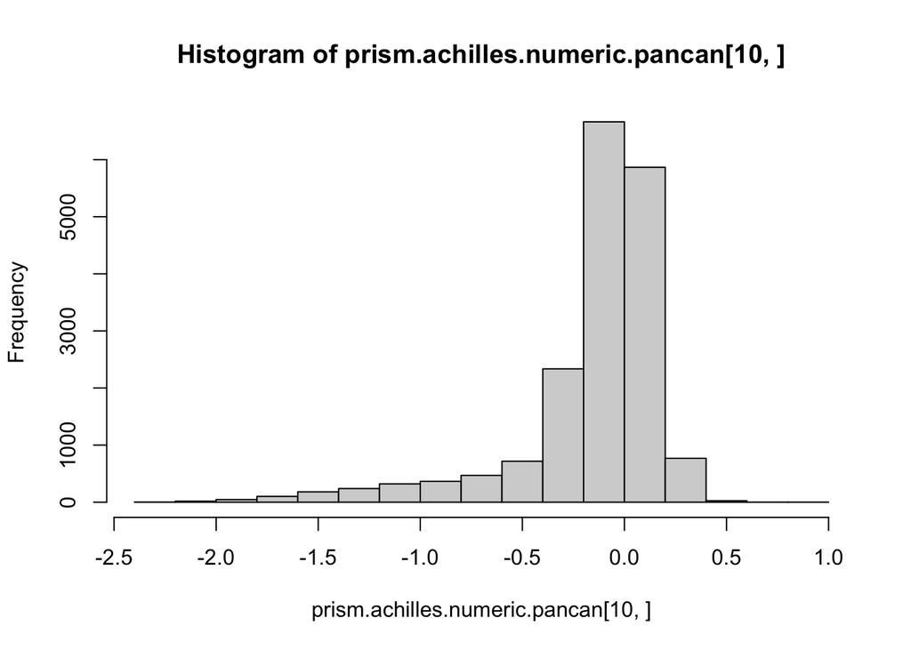

```r
hist(prism.achilles.numeric.pancan[10,])
```

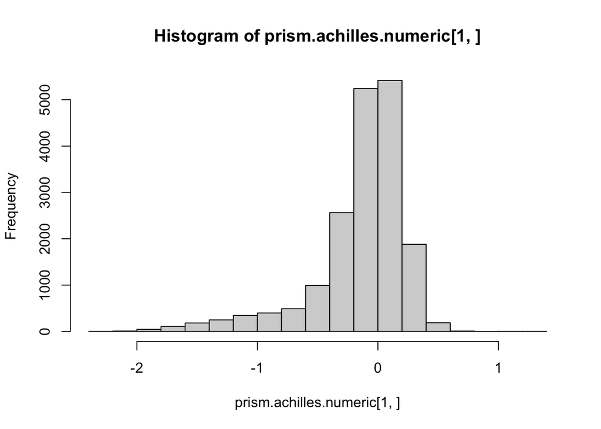

```r
hist(prism.achilles.numeric[1,])
```

```r
quantile(prism.achilles.numeric.pancan,probs=seq(0,1,.1))
```

```
##           0%          10%          20%          30%          40%          50%
## -3.013158370 -0.581997749 -0.287929545 -0.182443722 -0.113291797 -0.058112943
##          60%          70%          80%          90%         100%
## -0.007522533  0.042161024  0.097314728  0.169981701  2.390190374
```

```r
# checking that i can apply the quantile function...
quantile(prism.achilles.numeric,probs=seq(0,1,.1))
```

```
##           0%          10%          20%          30%          40%          50%
## -4.495161219 -0.595177702 -0.301276609 -0.191269511 -0.118877789 -0.060704660
##          60%          70%          80%          90%         100%
## -0.007980654  0.044477885  0.102514805  0.179948353  4.874965251
```

```r
quantile(prism.achilles.numeric,prob=0.1)
```

```
##        10%
## -0.5951777
```

```r
prism.achilles.numeric[345:347,1:5]
```

```
##                 A1BG        A1CF         A2M      A2ML1     A3GALT2
## ACH-001239 0.1437121  0.03772355 -0.14169312 0.20126637 -0.02146561
## ACH-001306 0.1699559  0.11702571 -0.16983882 0.07760954  0.02798856
## ACH-001318 0.2043360 -0.29032415  0.01755972 0.07387247 -0.10890666
```

```r
dim(prism.achilles.numeric)
```

```
## [1]   347 18119
```

```r
dim(prism.achilles)
```

```
## [1]   347 18119
```

```r
rownames(prism.achilles.numeric) <- rownames(prism.achilles)
```

New Dataframe for Analysis of prism.achilles.numeric

```r
# creates Dataframe with 10 rows and the same column count and names as prism.achilles
achilles.research.dataframe <- prism.achilles[1:10,]
# this sets all values of the research.dataframe to 0
achilles.research.dataframe[1:10,1:18119] <- 0
# this sets all rownames according to their future contents
rownames(achilles.research.dataframe) <- c('max','mean','min','10%quantile','Pancanmean','is(r5<r4)','stdev','empty8','empty9','empty10')

# fills first row of research.dataframe with the maximum value of the according prism.achilles.numeric column
achilles.research.dataframe[1,] <- apply(prism.achilles.numeric, 2, max)
# means of prism.achilles.numeric
achilles.research.dataframe[2,] <- apply(prism.achilles.numeric, 2, mean)
# min of prism.achilles.numeric
achilles.research.dataframe[3,] <- apply(prism.achilles.numeric, 2, min)
# 10% quantile of prism.achilles.numeric
achilles.research.dataframe[4,] <- apply(prism.achilles.numeric, 2, function(x){quantile(x,prob=0.1)})
# mean of prism.achilles.numeric.pancan
achilles.research.dataframe[5,] <- apply(prism.achilles.numeric.pancan, 2, mean)
# is 1 if mean of prism.achilles.numeric.pancan is smaller that 10% quantile of prism.achilles.numeric
achilles.research.dataframe[6,] <- apply(achilles.research.dataframe, 2, function(x) {return(x[4] > x[5])})
# var of prism.achilles.numeric
achilles.research.dataframe[7,] <- apply(prism.achilles.numeric, 2, var)
```

```r
achilles.research.dataframe[1:7,1]
```

```
## [1]  0.43862658  0.08860929 -0.23506619 -0.06972403  0.06241759  0.00000000
## [7]  0.01372463
```

```r
which(achilles.research.dataframe[6,] == 1)
```

```
## [1]  4283  7638  7955 17229
```

```r
achilles.research.dataframe[1:7,which(achilles.research.dataframe[6,] == 1)]
```

```
##                   DOCK5      KCNK13        KRAS         WLS
## max          0.43776386  0.53068373  0.06927002  0.41504652
## mean        -0.08222936 -0.03646742 -0.58201216  0.12194959
## min         -1.26474680 -2.36986289 -2.15523077 -0.80051723
## 10%quantile -0.35935966 -0.14240574 -1.28502818 -0.01467511
## Pancanmean  -0.41593873 -0.44466120 -1.30698799 -0.02380382
## is(r5<r4)    1.00000000  1.00000000  1.00000000  1.00000000
## stdev        0.05767614  0.09384127  0.17246569  0.01692432
```

```r
# these values show that the interesting columns are not completely normally distributed
shapiro.test(prism.achilles.numeric[,4283])
```

```
##
##  Shapiro-Wilk normality test
##
## data:  prism.achilles.numeric[, 4283]
## W = 0.88736, p-value = 2.696e-15
```

```r
shapiro.test(prism.achilles.numeric[,7638])
```

```
##
##  Shapiro-Wilk normality test
##
## data:  prism.achilles.numeric[, 7638]
## W = 0.63224, p-value < 2.2e-16
```

```r
shapiro.test(prism.achilles.numeric[,7955])
```

```
##
##  Shapiro-Wilk normality test
##
## data:  prism.achilles.numeric[, 7955]
## W = 0.84554, p-value < 2.2e-16
```

```r
shapiro.test(prism.achilles.numeric[,17229])
```

```
##
##  Shapiro-Wilk normality test
##
## data:  prism.achilles.numeric[, 17229]
## W = 0.85977, p-value < 2.2e-16
```

ggqqplot(prism.achilles.numeric[,4283]) ggqqplot(prism.achilles.numeric[,7638]) ggqqplot(prism.achilles.numeric[,7955]) ggqqplot(prism.achilles.numeric[,17229])

merlinsvariable <- 10000 cor.mat.achilles <- cor(prism.achilles.numeric.pancan[,1:merlinsvariable]) cor.mat.achilles[779,782] interesting.cor.values <- which(cor.mat.achilles > 0.90 & cor.mat.achilles < 1 ) interesting.cor.rows <- (((interesting.cor.values - (interesting.cor.values %% merlinsvariable)) /merlinsvariable) +1) interesting.cor.cols <- (interesting.cor.values %% merlinsvariable) cor.mat.achilles[interesting.cor.rows, interesting.cor.cols]

k-means clustering

Using the most variable, thus informative genes We first reduce our dataset to take the most variable gene, which are expected to carry most of the information about the samples:

```r
## compute variance over all rows of the data.frame (hence genes)
topVar = apply(prism.achilles.numeric, 2, var)
summary(topVar)
```

```
##     Min.  1st Qu.   Median     Mean  3rd Qu.     Max.
## 0.004248 0.012590 0.015523 0.020433 0.020707 0.503658
```

```r
## filtering to keep genes which have a variance greater than the 75% percentile
prism.achilles.numeric.topVar = prism.achilles.numeric[,topVar > quantile(topVar, probs = 0.75)]
dim(prism.achilles.numeric.topVar)
```

```
## [1]  347 4530
```

Clustering by depmap

```r
mydata <- prism.achilles.numeric.topVar
# Determine number of clusters
wss.depmap <- (nrow(mydata)-1)*sum(apply(mydata,2,var))
wss.depmap
```

```
## [1] 61682.45
```

```r
for (i in 2:100) wss.depmap[i] <- sum(kmeans(mydata, centers=i)$withinss)
```

```r
wss.depmap
```

```
##   [1] 61682.45 60064.82 59122.28 58299.77 57507.94 56999.55 56176.18 55975.21
##   [9] 55124.61 54782.36 54455.07 53845.01 53492.54 53218.90 52677.36 52424.59
##  [17] 52067.46 51945.07 51507.93 51184.68 50787.27 50532.48 50213.00 50135.42
##  [25] 49516.89 49276.67 49009.44 48760.76 48287.28 48007.35 47611.73 47634.60
##  [33] 47292.02 47273.97 46742.62 46495.71 46059.76 45937.34 45629.78 45447.00
##  [41] 45055.32 44926.51 44495.20 44370.15 44168.60 43954.09 43719.49 43397.64
##  [49] 43225.88 42935.90 43010.13 42398.71 42163.48 42053.56 41691.96 41609.16
##  [57] 41338.32 41000.92 40954.38 40564.96 40535.07 40280.98 39866.74 39661.03
##  [65] 39526.22 39405.35 39046.35 38886.91 38835.67 38471.23 38327.45 38042.50
##  [73] 37851.75 37726.25 37341.08 37330.81 36977.84 36918.63 36686.05 36606.25
##  [81] 36257.16 36039.77 35759.99 35521.24 35422.65 35312.67 35051.88 34965.83
##  [89] 34588.51 34603.33 34352.49 34160.03 33822.82 33841.65 33550.24 33330.35
##  [97] 33174.50 32981.73 32799.68 32685.04
```

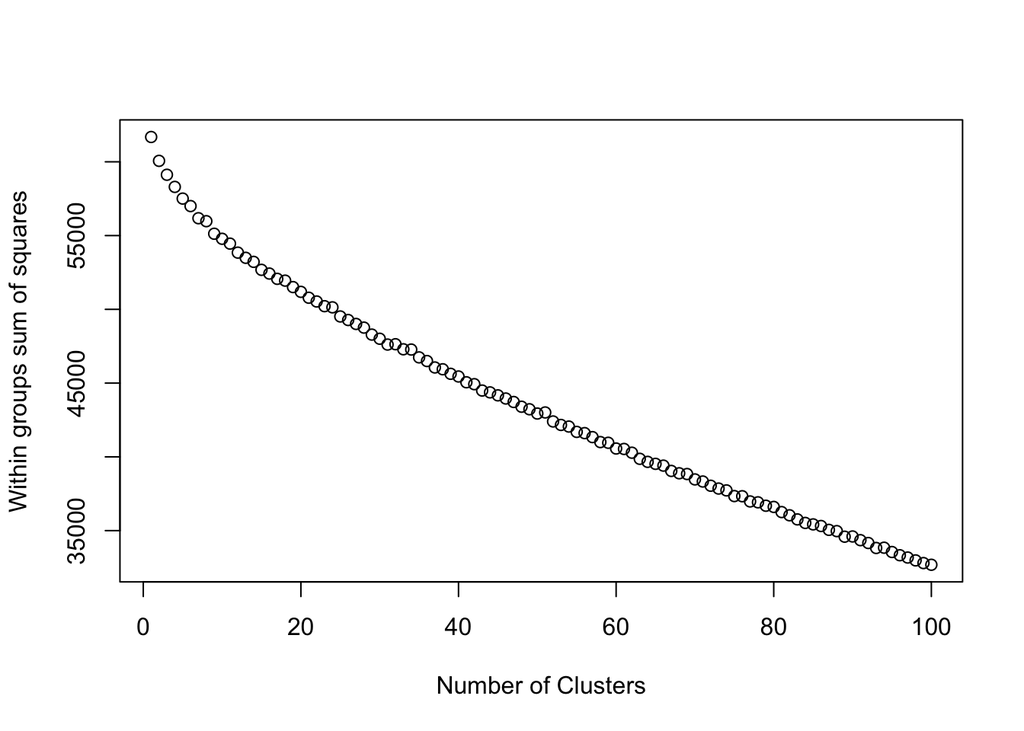

```r
plot(1:100, wss.depmap, type="b", xlab="Number of Clusters",
  ylab="Within groups sum of squares")
```

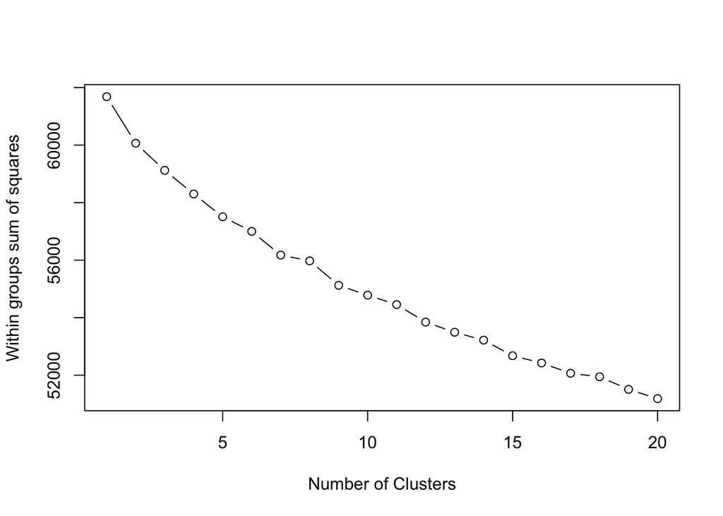

```r
plot(1:20, wss.depmap[1:20], type="b", xlab="Number of Clusters",
  ylab="Within groups sum of squares")
```

```r
km.depmap = kmeans(x=prism.achilles.numeric.topVar,
            centers = 2,
            nstart = 10)
km.depmap$cluster[1:10]
```

```
## ACH-000007 ACH-000011 ACH-000012 ACH-000013 ACH-000014 ACH-000015 ACH-000018
##          1          2          1          1          2          1          2
## ACH-000019 ACH-000021 ACH-000022
##          1          1          1
```

```r
summary(km.depmap)
```

```
##              Length Class  Mode
## cluster       347   -none- numeric
## centers      9060   -none- numeric
## totss           1   -none- numeric
## withinss        2   -none- numeric
## tot.withinss    1   -none- numeric
## betweenss       1   -none- numeric
## size            2   -none- numeric
## iter            1   -none- numeric
## ifault          1   -none- numeric
```

```r
pancan.cl.names
```

```
##  [1] "ACH-000022" "ACH-000042" "ACH-000060" "ACH-000108" "ACH-000118"
##  [6] "ACH-000138" "ACH-000164" "ACH-000178" "ACH-000222" "ACH-000235"
## [11] "ACH-000243" "ACH-000265" "ACH-000266" "ACH-000281" "ACH-000307"
## [16] "ACH-000320" "ACH-000332" "ACH-000468" "ACH-000502" "ACH-000517"
## [21] "ACH-000535" "ACH-000599" "ACH-000601" "ACH-000652" "ACH-000685"
```

```r
km.depmap$cluster[pancan.cl.names]
```

```
## ACH-000022 ACH-000042 ACH-000060 ACH-000108 ACH-000118 ACH-000138 ACH-000164
##          1          2          2          2          1          1          2
## ACH-000178 ACH-000222 ACH-000235 ACH-000243 ACH-000265 ACH-000266 ACH-000281
##          2          2          2          2          1          2          2
## ACH-000307 ACH-000320 ACH-000332 ACH-000468 ACH-000502 ACH-000517 ACH-000535
##          1          1          2          2          2          2          1
## ACH-000599 ACH-000601 ACH-000652 ACH-000685
##          2          2          1          1
```

```r
mydata <- prism.achilles.numeric.topVar
# Determine number of clusters

wss.genes <- (ncol(mydata)-1)*sum(apply(mydata,1,var))
dim(mydata)
```

```
## [1]  347 4530
```

```r
for (i in 500:501) wss.genes[i] <- sum(kmeans(t(mydata), centers=i, iter.max = 500)$withinss)
```

wss.genes dim(wss.genes) plot(wss.genes[100:1000], type=“b”, xlab=“Number of Clusters”, ylab=“Within groups sum of squares”) plot(wss.genes[100:500], type=“b”, xlab=“Number of Clusters”, ylab=“Within groups sum of squares”)

```r
km.genes = kmeans(x=prism.achilles.numeric.topVar,
            centers = 2,
            nstart = 10)
km.genes$cluster[1:10]
```

```
## ACH-000007 ACH-000011 ACH-000012 ACH-000013 ACH-000014 ACH-000015 ACH-000018
##          1          2          1          1          2          1          2
## ACH-000019 ACH-000021 ACH-000022
##          1          1          1
```

```r
summary(km.genes)
```

```
##              Length Class  Mode
## cluster       347   -none- numeric
## centers      9060   -none- numeric
## totss           1   -none- numeric
## withinss        2   -none- numeric
## tot.withinss    1   -none- numeric
## betweenss       1   -none- numeric
## size            2   -none- numeric
## iter            1   -none- numeric
## ifault          1   -none- numeric
```

```r
pancan.cl.names
```

```
##  [1] "ACH-000022" "ACH-000042" "ACH-000060" "ACH-000108" "ACH-000118"
##  [6] "ACH-000138" "ACH-000164" "ACH-000178" "ACH-000222" "ACH-000235"
## [11] "ACH-000243" "ACH-000265" "ACH-000266" "ACH-000281" "ACH-000307"
## [16] "ACH-000320" "ACH-000332" "ACH-000468" "ACH-000502" "ACH-000517"
## [21] "ACH-000535" "ACH-000599" "ACH-000601" "ACH-000652" "ACH-000685"
```

```r
km.genes$cluster[pancan.cl.names]
```

```
## ACH-000022 ACH-000042 ACH-000060 ACH-000108 ACH-000118 ACH-000138 ACH-000164
##          1          2          2          2          1          1          2
## ACH-000178 ACH-000222 ACH-000235 ACH-000243 ACH-000265 ACH-000266 ACH-000281
##          2          2          2          2          1          2          2
## ACH-000307 ACH-000320 ACH-000332 ACH-000468 ACH-000502 ACH-000517 ACH-000535
##          1          1          2          2          2          2          1
## ACH-000599 ACH-000601 ACH-000652 ACH-000685
##          2          2          1          1
```